# Factors effect hotel booking demand

ABCDE: Ziming Lei, Yi Wei, Ruijing Jiang, Yutong Zhu, Laurence Yao

2026-11-28

## Research Question

Hotel booking demand can be influenced by various factors, including seasonal patterns, room prices, customer composition and customer requirements.

Understanding these factors is important for hotels because it may help them better understand customer behaviour and manage their resources.

This project aims to investigate the factors associated with hotel booking demand using the Hotel Booking Demand dataset. In particular, we focus on four aspects:

1.The relationship between arrival months and reservation frequency 2.The distribution of average daily rates (ADR) 3.Differences in guest composition between City Hotels and Resort Hotels 4.Customer demand for car parking spaces

We aim to identify patterns and differences in booking demand and gain a better understanding of hotel customer behaviour.

## Data

This project uses the Hotel Booking Demand dataset, which contains hotel reservation records for two types of hotels: City Hotels and Resort Hotels.

The dataset includes information about hotel bookings, arrival dates, room prices and guest characteristics. Several key variables are selected for our investigation.

These include `arrival_date_month` and `arrival_date_year`, which describe the timing of hotel arrivals; `adr`, which represents the Average Daily Rate; `adults`, `children` and `babies`, which describe guest composition; and `required_car_parking_spaces`, which records the number of car parking spaces requested.

These variables allow us to explore seasonal booking patterns, room price distributions, differences in guest composition and customer parking requirements.

Before conducting the analysis, relevant variables were checked for missing values. The data were also processed to ensure that the variables were in suitable formats for analysis.

The dataset is publicly available on Kaggle: https://www.kaggle.com/datasets/mojtaba142/hotel-booking

## Findings

-3.1 Seasonal Booking Patterns

```
## # A tibble: 1 × 2
##   missing_month missing_year
##           <int>        <int>
## 1             0            0
```

```
## [1] 0
```

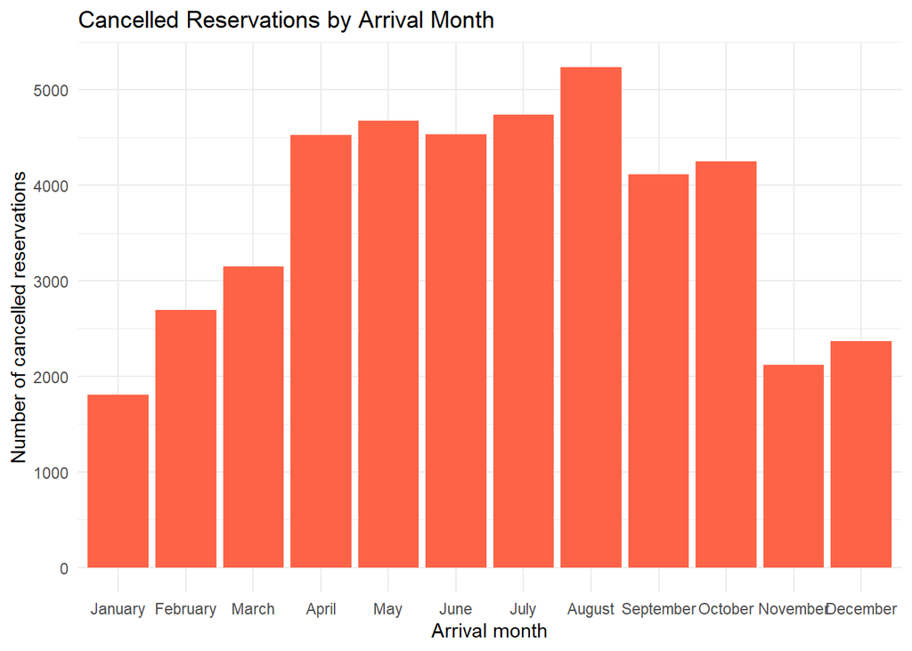

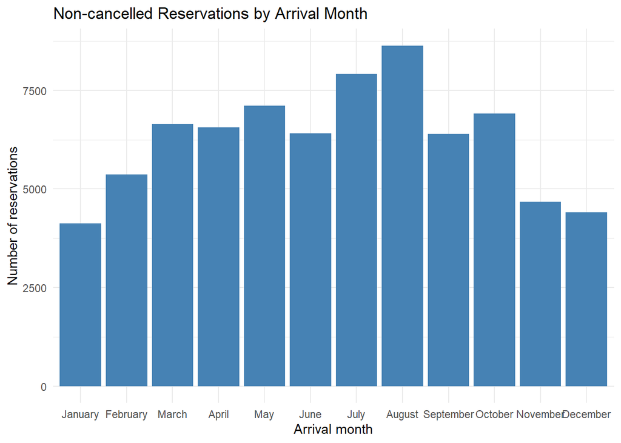

```
## # A tibble: 12 × 2
##    arrival_date_month reservations
##    <ord>                     <int>
##  1 August                     8638
##  2 July                       7919
##  3 May                        7114
##  4 October                    6914
##  5 March                      6645
##  6 April                      6565
##  7 June                       6404
##  8 September                  6392
##  9 February                   5372
## 10 November                   4672
## 11 December                   4409
## 12 January                    4122
```

In this part, we look at how the number of hotel reservations changes in different months. We use a bar chart to show the number of reservations in each month.

From the chart, we can see that more people book hotels during the summer, especially in August. In comparison, there are fewer bookings during the winter months. This may be because more people choose to travel during the summer holidays.

-3.2 Room Price Distribution

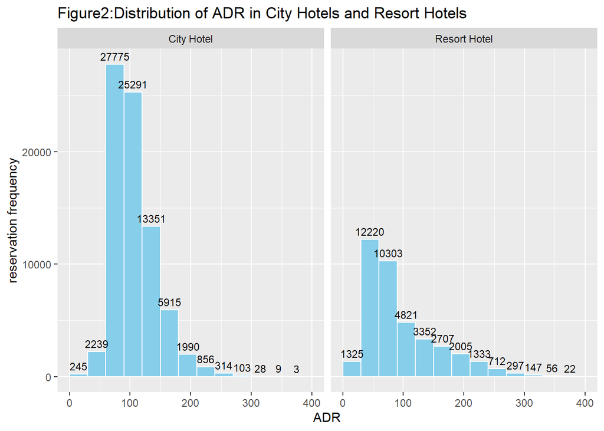

In this part, we look at the relationship between ADR and the number of reservations for City Hotels and Resort Hotels. We use histograms to compare the distribution of ADR in the two types of hotels.

As shown in Figure 2, most City Hotel reservations have an ADR between around £60 and £150. The highest frequency is found between £60 and £90. For Resort Hotels, most reservations have a lower ADR, mainly between around £30 and £100. The number of reservations generally decreases as ADR increases in both types of hotels.

Overall, the chart shows that City Hotels tend to have higher ADR values than Resort Hotels. This suggests that the two types of hotels have different room price ranges and booking patterns.

-3.3 Guest Composition

```
## # A tibble: 8 × 4
##   hotel        guest_group            n percentage
##   <chr>        <chr>              <int>      <dbl>
## 1 City Hotel   Adults only        73756   0.932
## 2 City Hotel   With babies only     297   0.00375
## 3 City Hotel   With both             72   0.000910
## 4 City Hotel   With children only  5034   0.0636
## 5 Resort Hotel Adults only        36118   0.902
## 6 Resort Hotel With babies only     445   0.0111
## 7 Resort Hotel With both            103   0.00257
## 8 Resort Hotel With children only  3381   0.0844
```

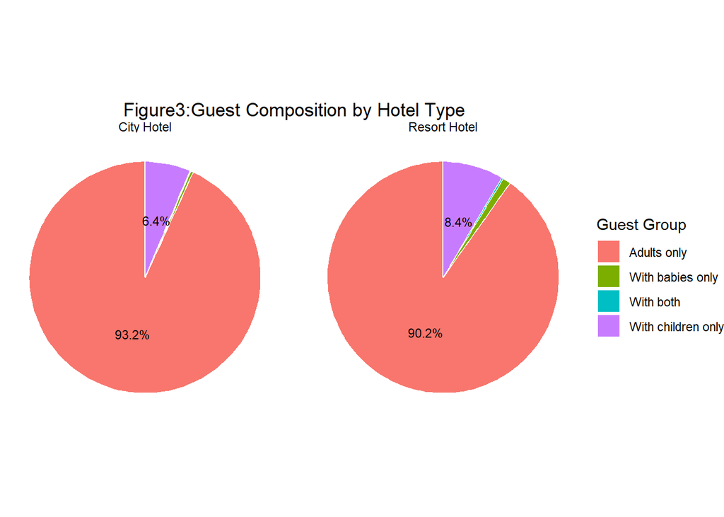

In this part, we compare the different guest groups in City Hotels and Resort Hotels. We divide the guests into four groups based on the numbers of adults, children and babies. Pie charts are used to show the percentage of each group.

As shown in Figure 3, adults only is the largest group in both types of hotels. It makes up 93.2% of City Hotel bookings and 90.2% of Resort Hotel bookings. The percentage of guests with children only is higher in Resort Hotels (8.4%) than in City Hotels (6.4%).

Overall, the results show that most hotel bookings are made by adults travelling without children or babies. Resort Hotels have a slightly higher percentage of guests travelling with children. This may suggest that Resort Hotels are more popular with families.

-3.4 Customer Parking Requirements

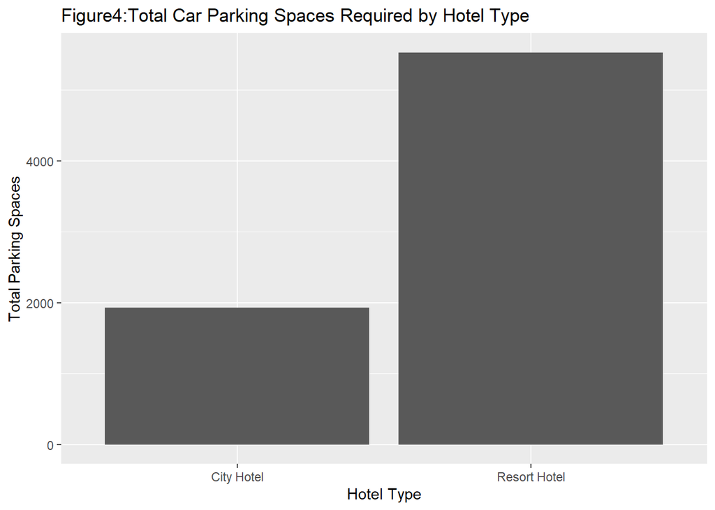

[output not shown]

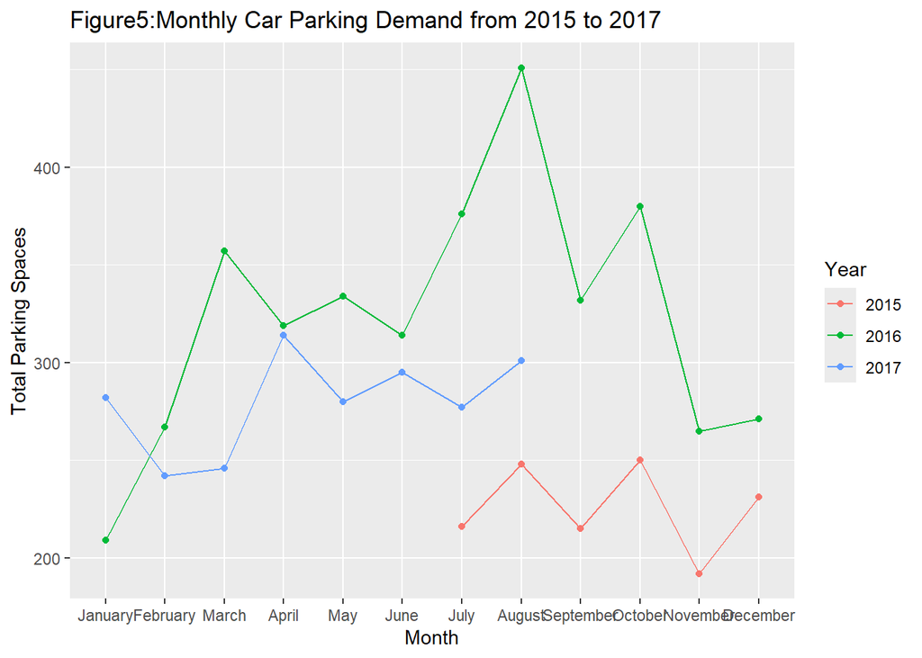

In this part, we investigate the demand for car parking spaces at City Hotels and Resort Hotels. We use a bar chart to compare the total parking spaces required by the two hotel types. We also use a line chart to show how parking demand changes across different months and years.

Figure 5 shows the monthly changes in parking demand from 2015 to 2017. In 2016, parking demand reaches its highest point in August, with around 450 spaces requested. In 2015, the highest demand is in October, while in 2017, it is in April. We can also see that parking demand changes across different months and years.

Overall, the results show that Resort Hotels have a higher total demand for parking spaces. There are also differences in monthly parking demand between different years. These results may help hotels understand their customers’ parking needs and prepare enough parking spaces.

-3.5 Discussion and Conclusion Overall, our analysis shows that City Hotels and Resort Hotels have some differences in booking patterns and customer characteristics. August has the highest number of reservations, while January has the lowest. City Hotels generally have higher ADR values, while Resort Hotels have more guests travelling with children and a higher demand for parking spaces.

Despite these limitations, this project has helped us understand the differences between City Hotels and Resort Hotels. It also shows that seasonal patterns, room prices, guest groups and parking requirements are useful factors to consider when studying hotel booking demand.

## References

mojtaba142 (n.d.). *Hotel Booking*. Kaggle. Available at: https://www.kaggle.com/datasets/mojtaba142/hotel-booking